# Report on Portfolio Expertise

Spain

Number of observations

```
Spain
  431
```

# I. Level A: within and across each dimension

## Academic expertise

#### Figure A1: Level of education and relation to portfolio

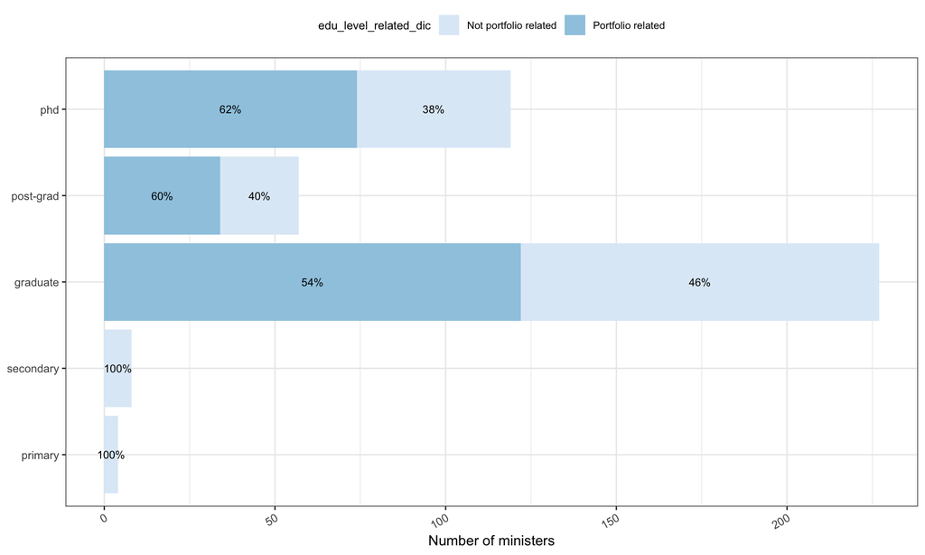

*Figure A1. Level of education and relation to portfolio (Spain, ministerial appointments, N=415).*

General pattern: Spanish ministers show a similarly high level of educational attainment to their Portuguese counterparts, though with a somewhat longer tail below graduate level. PhD holders account for 28.7% of all ministers (119/415), postgraduate (non-PhD) degree holders for 13.7% (57/415), and graduate-only degree holders for 54.7% (227/415). A small residual falls below graduate level: 1.9% (8/415) with secondary education only and 1.0% (4/415) with primary education only, the latter a category entirely absent from the Portuguese sample. Overall, 97.1% of Spanish ministers hold at least a graduate degree, close to but slightly below Portugal’s 98.4%.

With portfolio relation: Overall relatedness is somewhat lower in Spain than in Portugal (55.4%, 230/415, against 60.0% in Portugal). Unlike Portugal, where relatedness followed a non-monotonic, “hump-shaped” pattern (highest among postgraduate non-PhD holders at 80.0%, then PhD at 63.8%, then graduate-only at 56.1%), Spain shows a clean monotonic increase with educational level: 53.7% among graduate-only degree holders, 59.6% among postgraduate non-PhD holders, and 62.2% among PhD holders. Both countries agree that secondary-only education carries zero portfolio relation (0/8 in Spain, 0/8 in Portugal); Spain’s four primary-only ministers show the same pattern (0/4 related). The cross-country contrast is therefore not in direction (education level modestly favors relatedness in both cases) but in shape and magnitude: Portugal’s peak (80.0% at postgraduate non-PhD level) is considerably steeper than Spain’s ceiling (62.2% at PhD level), suggesting a less pronounced credential-relatedness gradient in the Spanish case.

#### Figure A2: Field of education, by level

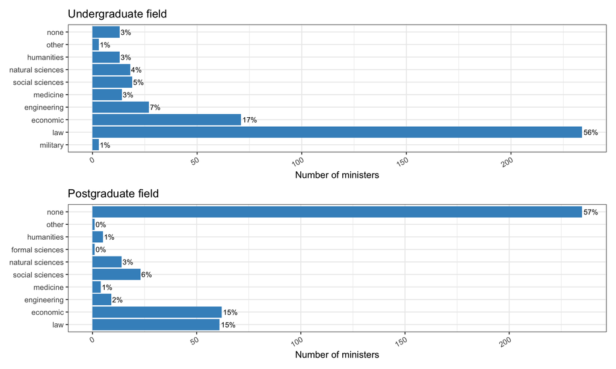

*Figure A2. Field of education, undergraduate and postgraduate (Spain, ministerial appointments, N=415).*

At the undergraduate level, Law dominates even more heavily in Spain than in Portugal: 56.4% of ministers (234/415), against 38.5% in Portugal. Economics follows at 17.1% (71/415), broadly comparable to Portugal’s 19.9%. The most striking divergence is Engineering, Portugal’s second-largest undergraduate field (22.5%), which is comparatively marginal in Spain (6.5%, 27/415). Natural Sciences, negligible in Portugal (0.8%), is noticeably more present in Spain (4.3%, 18/415), and the share reporting no undergraduate field is roughly double (3.1%, 13/415, against 1.6% in Portugal).

At the postgraduate level, the dominant pattern again is the absence of further education, slightly more pronounced than in Portugal (56.6% with no postgraduate degree, 235/415, against 54.0%). Among those who do continue, Law and Economics are essentially tied (14.7%, 61/415, and 14.9%, 62/415, respectively), with Economics marginally ahead, unlike Portugal, where Law led at every stage (12.8% against Economics’ 12.2%). Engineering’s postgraduate share is much lower in Spain (2.2%) than in Portugal (6.1%), consistent with its smaller undergraduate footprint. Management, a small but non-zero postgraduate niche in Portugal (2.8%), is entirely absent in the Spanish sample (0%), at both undergraduate and postgraduate level.

#### Figure A3: Field of education, by relation to the portfolio

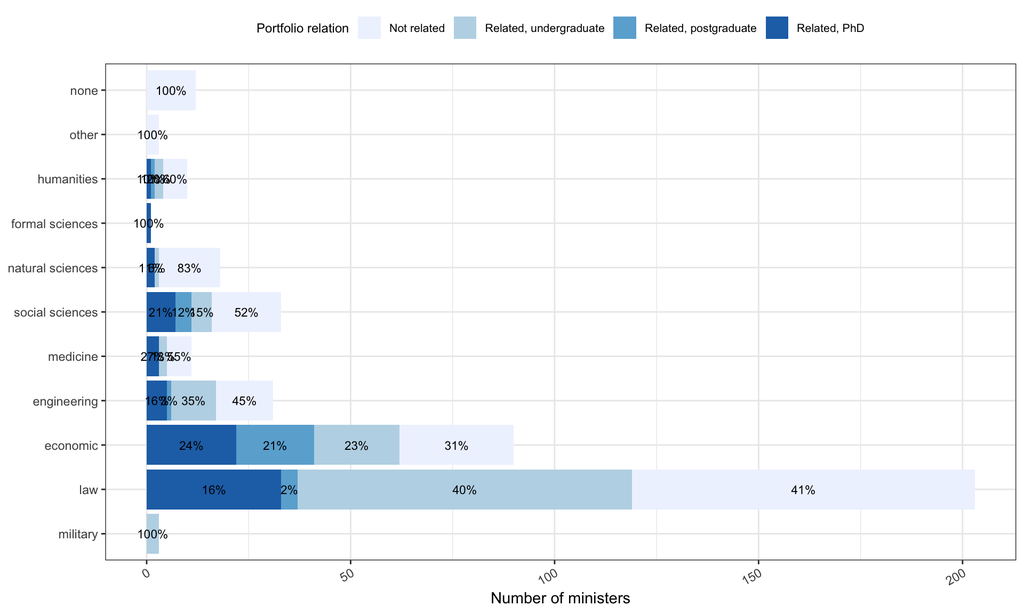

*Figure A3. Field of the highest degree attained, by relation to the portfolio (Spain, ministerial appointments, N=415). Bars show the field of each minister’s highest educational qualification; segments show whether, and at which level, any of the minister’s education is related to the substantive area of their portfolio (graduate, postgraduate non-PhD, or PhD).*

Military education again shows the highest relatedness of any field, and again entirely at graduate level: 100% (3/3) in Spain, against 92.9% (13/14) in Portugal, both on small N.

Law and Economics, the two largest fields, diverge from each other differently than in Portugal. Law shows 41.4% no relation (84/203), close to Portugal’s 39.4%, but the distribution of related cases is more concentrated at the first-degree level (40.4% graduate-related) with a nearly empty postgraduate non-PhD tier (2.0%, against Portugal’s 12.2%) and a larger PhD-related share (16.3%, against 11.1%). Economics shows a higher no-relation share than in Portugal (31.1% against 23.9%) and a markedly flatter spread across the three related tiers (23.3% graduate, 21.1% postgraduate, 24.4% PhD), instead of Portugal’s graduate-heavy pattern (38.1% graduate against only 12.4% postgraduate).

Engineering keeps a similarly low overall relatedness in both countries (45.2% not related in Spain against 47.1% in Portugal), with postgraduate-level relation concentrated at PhD level in both cases (16.1% against 3.2% non-PhD postgraduate in Spain; 12.9% against 3.5% in Portugal). Medicine and Social Sciences diverge more sharply: Medicine shows markedly lower relatedness in Spain (45.5% related overall, against 81.2% in Portugal, both on small N and to be read with caution), while Social Sciences shows markedly higher relatedness in Spain (48.5% related, against 26.1% in Portugal). Natural Sciences, too small to assess in Portugal (N=1), is analyzable in Spain (N=18) and shows very low relatedness (83.3% not related). Humanities shows lower relatedness in Spain (60.0% not related, against 38.5% in Portugal).

As an internal consistency check: the four column totals in A3 (185 not related, 127 related at graduate level, 29 at postgraduate non-PhD level, 74 at PhD level) match exactly the marginal distribution of edu_level_related for the full sample, and the 12 ministers with no field (“none”) are all classified as not related, consistent with the 8 secondary-only and 4 primary-only ministers identified in A1 (8+4=12).

#### Figure A4: Academic dimension

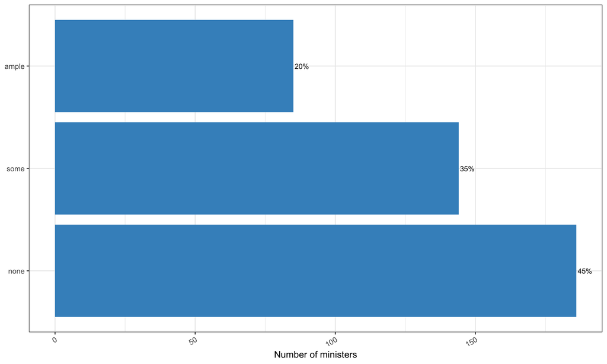

*Figure A4. Distribution of academic expertise (Spain, ministerial appointments, N=415).*

The aggregated academic dimension shows 44.8% of ministers (186/415) with no academic expertise, 34.7% (144/415) with some, and 20.5% (85/415) with ample. The ample share is nearly identical to Portugal’s (20.5% against 20.9%): both countries produce roughly one academically ample minister in five. The difference lies at the bottom of the scale: Spain has a markedly higher none share (44.8% against Portugal’s 40.0%) and a correspondingly lower some share (34.7% against 39.1%), consistent with Spain’s somewhat lower overall portfolio-relatedness already noted in Figure A1 (55.4% against 60.0%).

## Occupational Dimension

#### Figure A5: Prior occupation, by relation to the portfolio

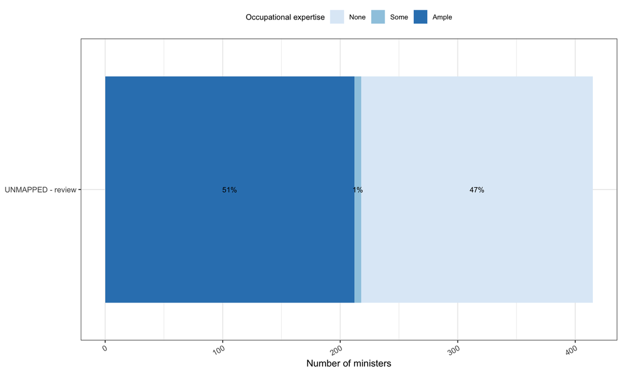

*Figure A5. Prior occupational background, by occupational expertise (Spain, ministerial appointments, N=415). Bars show ministers’ occupational background prior to appointment, aggregated into nine career families (expertise_Job_type_agg); segments show the level of occupational expertise (expertise_Job: none/some/ample) associated with that background.*

DATA GAP, not drafted: the underlying variable (expertise_Job_type_agg, the classification into nine occupational-career families) is unmapped for 100% of Spanish cases (415/415 “UNMAPPED - review”). It is not possible to describe which prior occupation is modal, nor whether it translates into higher occupational expertise, until this variable is coded. Pending recoding before this block can be drafted.

#### Figure A6: Occupational dimension

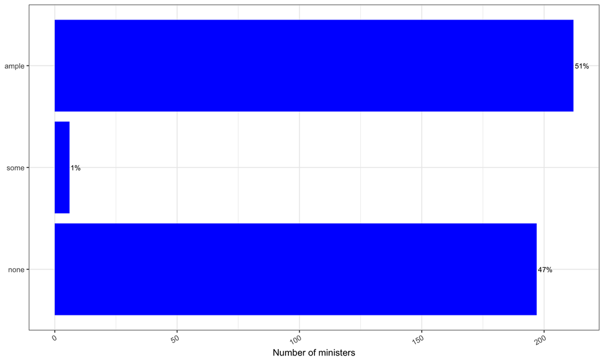

*Figure A6. Distribution of occupational expertise (Spain, ministerial appointments, N=415).*

The aggregated occupational dimension shows 47.5% of ministers (197/415) with no occupational expertise, only 1.4% (6/415) with some, and 51.1% (212/415) with ample. This is a strikingly bimodal distribution: ministers split almost evenly between the two extremes, with the intermediate category nearly empty. This contrasts sharply with Portugal’s much more graduated spread (22.3% none, 34.3% some, 43.4% ample). Given that the underlying occupational-family variable is unmapped for Spain (see Figure A5), this near-absence of the “some” category should be read with some caution: it may reflect a genuine substantive feature of Spanish ministerial recruitment, but it could also be sensitive to how “some” is triggered at the coding stage, which cannot currently be cross-checked against the raw occupational categories. To confirm by the country-expert once the coding underlying A5 is complete.

## Managerial Dimension

#### Figure A7: Managerial experience sector

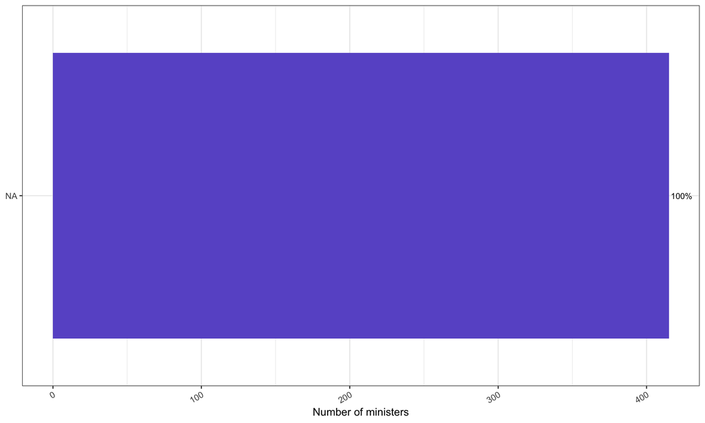

*Figure A7. Sector of prior managerial experience (Spain, ministerial appointments, N=415).*

DATA GAP, not drafted: the variable expertise_Manag_type (sector of prior managerial experience: none/private/public/both) is entirely missing for Spain (415/415 NA). No information is currently available on which sector prior managerial experience is concentrated in. Pending coding.

#### Figure A8: Managerial experience sector, by level of managerial expertise

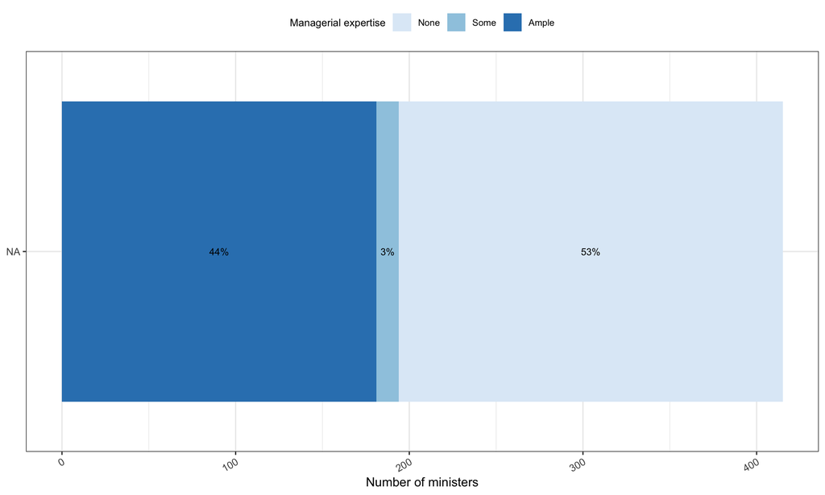

*Figure A8. Sector of managerial experience, by managerial expertise (Spain, ministerial appointments, N=415).*

DATA GAP, partial: the breakdown by sector is not analyzable, for the same reason as A7 (sector 100% missing). The only usable figure in this table is the managerial-expertise marginal (221 none / 13 some / 181 ample), which is identical to Figure A10 and is discussed there; it should not be repeated here as if it were a finding specific to A8.

#### Figure A9: Occupational background, by managerial expertise

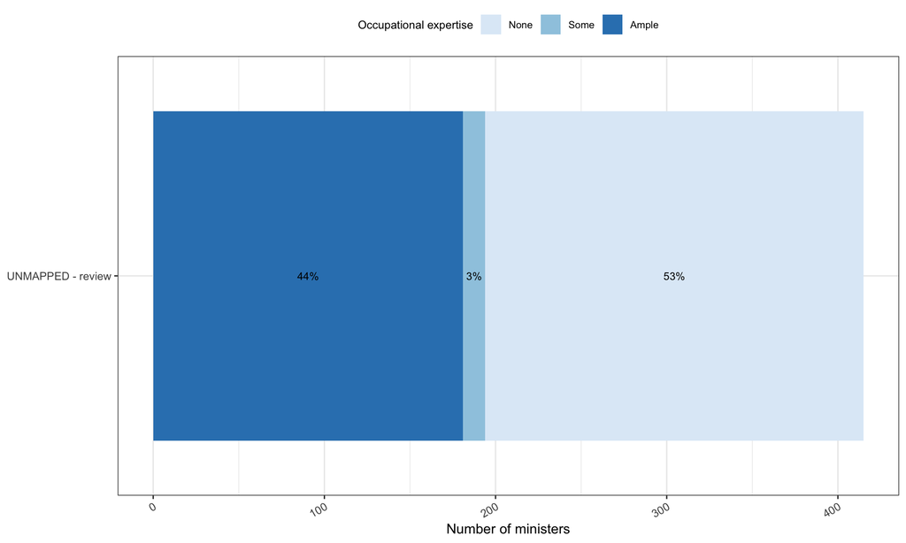

*Figure A9. Occupational background, by managerial expertise (Spain, ministerial appointments, N=415).*

DATA GAP, not drafted: same problem as A5, this table depends on expertise_Job_type_agg, unmapped for 100% of cases. It is not possible to identify which occupational backgrounds generate higher managerial expertise until that variable is coded.

#### Figure A10: Managerial dimension

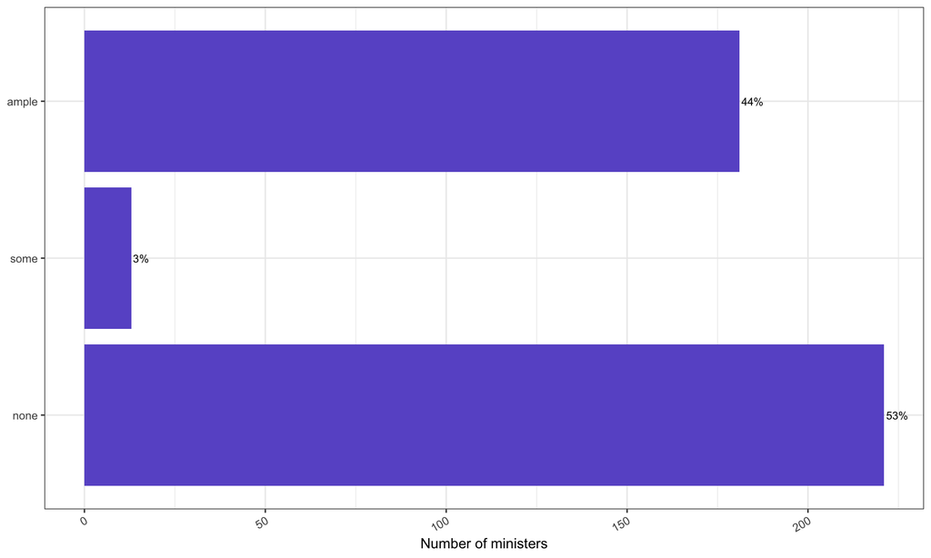

*Figure A10. Distribution of managerial expertise (Spain, ministerial appointments, N=415).*

The aggregated managerial dimension shows 53.3% of ministers (221/415) with no managerial expertise, only 3.1% (13/415) with some, and 43.6% (181/415) with ample. As with the occupational dimension (Figure A6), this is a strongly bimodal distribution, and it contrasts even more sharply with Portugal, where none was the smallest category (15.2%) and some the largest (43.8%): in Spain the ranking is reversed at the bottom, with none far more common than some. The ample share is comparable across countries (43.6% Spain against 41.0% Portugal): both countries generate ample managerial expertise in roughly two out of five ministers, but Spain reaches that ample rate from a much larger pool of ministers with no managerial experience at all, rather than through a broad middle tier. As with A6, the missing raw sector variable (A7/A8) means the substantive drivers of this bimodality cannot currently be unpacked further.

# II. Level B: Bivariate relations between dimensions

## Figure B1: Co-occurrence among academic, occupational, and managerial expertise

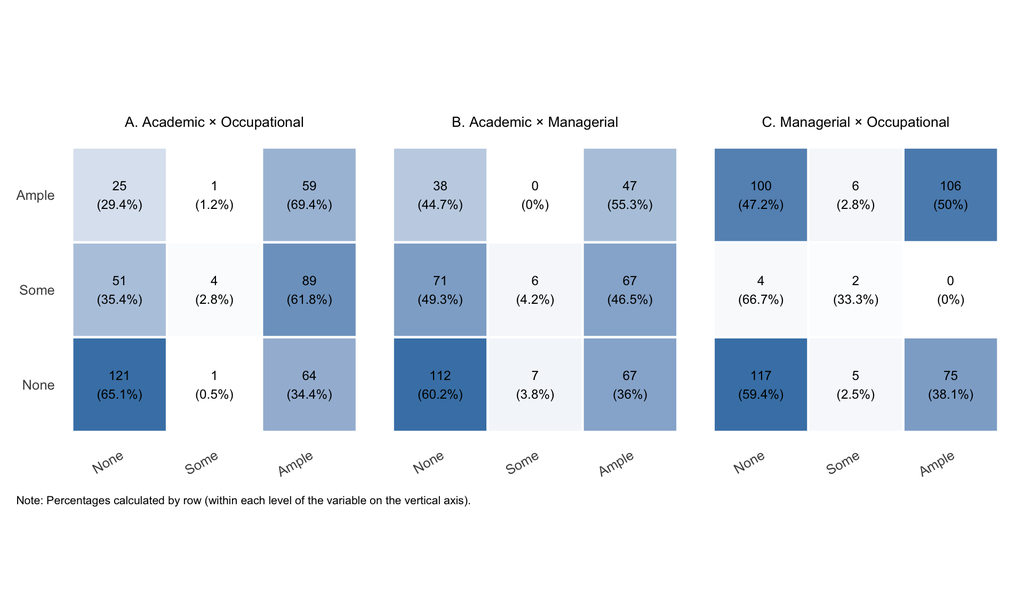

*Figure B1. Co-occurrence among academic, occupational, and managerial expertise (Spain, ministerial appointments, N=415). Each panel cross-tabulates one pair of expertise dimensions; percentages are calculated by row, within each level of the dimension on the vertical axis.*

## Figure B2: Correlations among academic, occupational, and managerial expertise

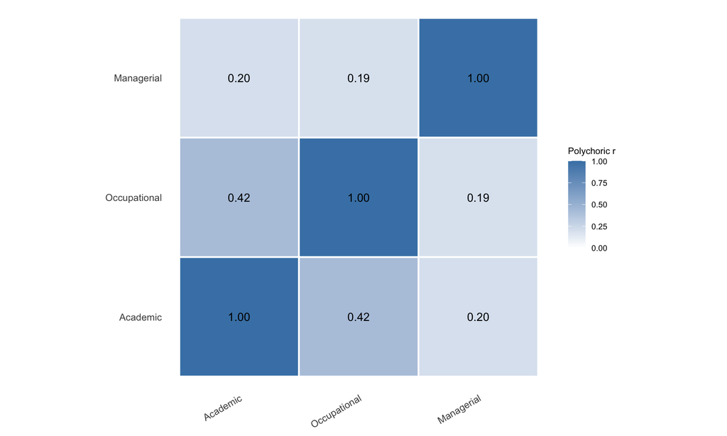

*Figure B2. Polychoric correlations among academic, occupational, and managerial expertise (Spain, ministerial appointments, N=415).*

Academic-occupational. The polychoric correlation is moderate (r = 0.42), close to Portugal’s 0.45 and the strongest pair in both countries. The gradient is positive: ample occupational expertise rises from 34.4% (Academic none) to 61.8% (some) to 69.4% (ample). The discordant corners reveal an important cross-country difference: the none/ample corner is similar to Portugal’s (34.4% against 27.1%), but the ample/none corner is far larger in Spain: 29.4% of ministers with ample academic expertise show no occupational expertise at all, against only 5.7% in Portugal. Where Portugal’s association held strongly at the top and loosened only at the bottom, Spain’s association is more symmetrically loose at both extremes.

Academic-managerial. The polychoric correlation is weak (r = 0.20), slightly stronger than Portugal’s 0.12 but still one of the two weakest pairs, together with occupational-managerial below. The gradient is modest (36.0% → 46.5% → 55.3% ample managerial expertise across academic levels). The ample/none corner is again far larger than in Portugal: 44.7% of academically ample ministers have no managerial expertise, against 13.2% in Portugal, a substantial cross-country gap. Spain’s most academically credentialed ministers are markedly less likely to also carry managerial experience than Portugal’s.

Occupational-managerial. The polychoric correlation is weak (r = 0.19), notably weaker than Portugal’s 0.33, where this pair was the second-strongest. The gradient across the some row (66.7% none / 33.3% some / 0.0% ample) should not be read as a substantive dip: it rests on only 6 cases, the same 6 ministers flagged in Figure A6 as the entire some-occupational category, and is noise rather than signal. Reading only the none and ample rows, ample managerial expertise rises from 38.1% (Job none) to 50.0% (Job ample), a real but modest gradient, and the ample/none corner is large (47.2%, against Portugal’s 10.0%).

Taken together, Spain’s polychoric matrix has a different shape from Portugal’s. In Portugal, the three pairs were graded: academic-occupational strongest (0.45), occupational-managerial intermediate (0.33), academic-managerial weakest (0.12). In Spain, academic-occupational is again clearly the strongest (0.42), but the other two pairs are close to tied and both weak (0.20 and 0.19): managerial expertise is roughly equally distant from both other dimensions, rather than closer to occupational as in Portugal. If anything, this gives even stronger support in the Spanish data than in the Portuguese data for treating managerial expertise as a genuinely independent dimension, not redundant with either of the other two.

As an internal consistency check: the row totals in both t_AcaJob and t_AcaManag (186 none, 144 some, 85 ample) match each other and the A4 marginal; the row totals in t_JobManag (197 none, 6 some, 212 ample) match exactly the overall occupational expertise distribution already reported in A6.

# Level C: Joint structure of the three dimensions

## Figure C1: Multidimensionality of the expertise space (Eigenvalues)

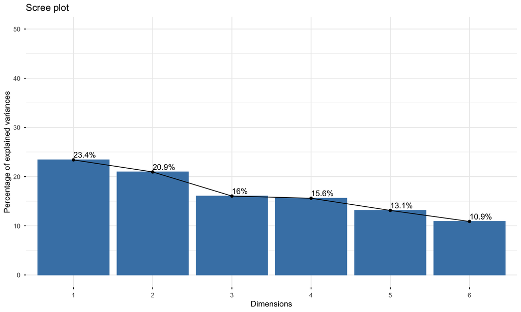

*Figure C1. Eigenvalues / percentage of inertia by axis, MCA of academic, occupational, and managerial expertise (Spain, ministerial appointments, N=415).*

The first axis accounts for 23.40% of total inertia, close to Portugal’s 24.96% and, as in Portugal, far short of what a single dominant dimension would require. The remaining axes decline gradually (20.95%, 16.05%, 15.60%, 13.12%, 10.88%), and four axes are needed to reach 76.0% of total inertia, matching Portugal’s four-axes-to-75.4% threshold almost exactly. If anything, Spain’s inertia is even more evenly spread at the top than Portugal’s: the gap between the first and second axes is only 2.45 points in Spain (23.40 against 20.95), against 6.51 points in Portugal (24.96 against 18.45). This reinforces, if anything slightly more strongly than in Portugal, the conclusion that the expertise space is genuinely multidimensional rather than reducible to a single technocratic gradient.

## Figure C2: Dimensional structure of the axes (eta²)

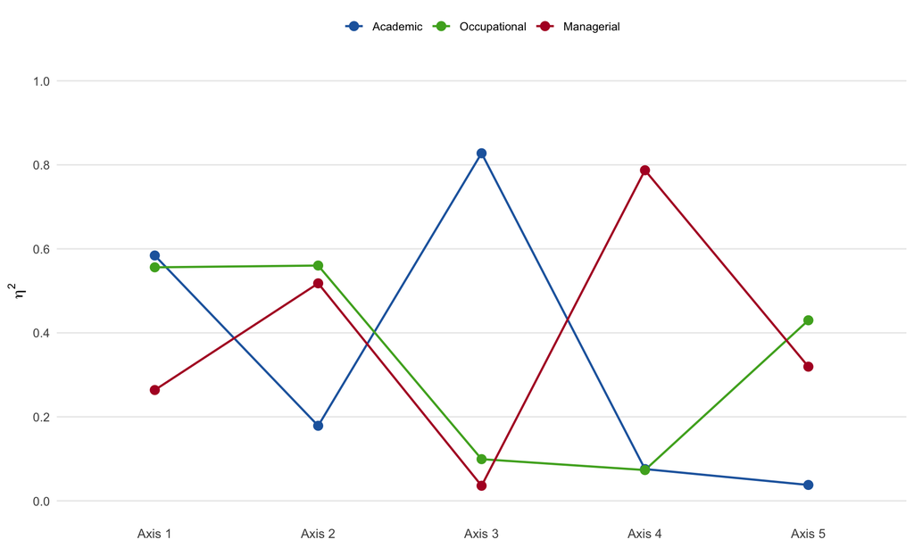

*Figure C2. Association (η²) between each expertise dimension and each MCA axis (Spain, ministerial appointments, N=415). Axis n corresponds to MCA Dimension n; terminology follows the program convention (see glossary).*

Axis 1 combines Academic (η² = 0.58) and Occupational (η² = 0.56), almost exactly tied, with Managerial weaker (η² = 0.26); Portugal’s Axis 1 was similarly occupational-academic, though there Occupational led more clearly (0.67 against 0.50). Axis 2 combines Occupational (0.56) and Managerial (0.52), both strong and nearly tied, with Academic weak (0.18): Portugal’s Axis 2 was also occupational-led (0.57) but with a considerably weaker managerial loading (0.38), so Spain’s second axis reads more clearly as a joint occupational-managerial axis than Portugal’s. Axis 3 is academic-specific (η² = 0.83) and essentially orthogonal to both other dimensions (Job = 0.10, Manag = 0.04): an even cleaner separation than Portugal’s Axis 3, which isolated academic from occupational (η² = 0.01) but still carried a non-trivial managerial loading (0.37). Axis 4 is managerial-specific (η² = 0.79), with academic and occupational both negligible (0.08 and 0.07): again a cleaner separation than Portugal’s Axis 4 (0.54, with academic non-negligible at 0.30). Axis 5 is mixed, dominated by Occupational (0.43) and Managerial (0.32) with Academic weak (0.04), a residual axis in both countries. Overall, each dimension again has at least one axis on which it dominates and the others are weak, as in Portugal, but Spain’s dimension-specific axes (3 and 4) show sharper, more orthogonal separation than Portugal’s equivalent axes.

## Configurations of expertise (clusters)

### Step 1: Automatic (data-driven) solution

#### Figure C3: Cluster sizes (automatic solution)

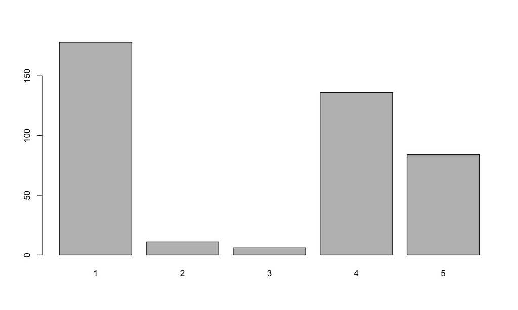

*Figure C3. Size of the clusters retained by the automatic (data-driven) HCPC solution (Spain, ministerial appointments, N=415).*

Unlike Portugal, where the unconstrained automatic solution returned four clusters (later refined to five for theoretical alignment), Spain’s automatic solution already returns five clusters directly, with no forcing needed: 178 (42.9%), 11 (2.7%), 6 (1.5%), 136 (32.8%), and 84 (20.2%) ministers. The distribution is considerably more skewed than Portugal’s final five-cluster solution (which ranged narrowly between 15% and 20% for its smaller four clusters): Spain has two very small clusters (11 and 6 cases) alongside three much larger ones. Given that the automatic solution already yields five clusters unforced, Steps 2 and 3 (theory-driven forcing) are not run for Spain; the automatic solution is adopted directly as cluster_final.

### Steps 2 & 3 — Data Manager task only (theory-driven alternative, if applicable)

### Step 4: Cluster profiles by expertise dimension

#### Figure C4: Cluster profile, by expertise dimension

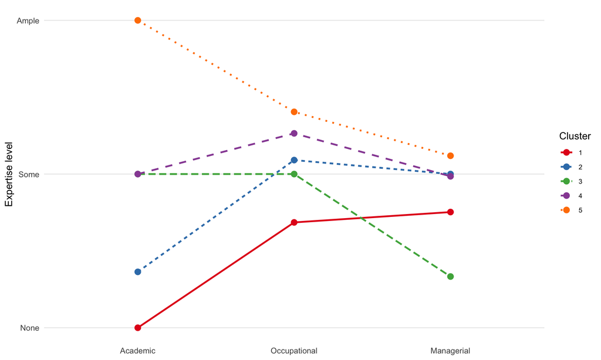

*Figure C4. Mean expertise level per dimension, by cluster (Spain, ministerial appointments, N=415). Clusters identified by number only; substantive labels are assigned in Step 5, after inspecting this profile.*

Three of the five clusters are defined almost purely by academic expertise level, each corresponding to exactly one rung of the trichotomous scale: Cluster 1 (N=178, 42.9%) is 100% academic-none (mean 1.00), with low-to-moderate occupational (1.69) and managerial (1.75) expertise; Cluster 4 (N=136, 32.8%) is 100% academic-some (mean 2.00), with moderately high occupational (2.26) and low-to-moderate managerial (1.99) expertise; Cluster 5 (N=84, 20.2%) is 100% academic-ample (mean 3.00), with moderately high occupational (2.40) and managerial (2.12) expertise, the closest Spanish analogue to Portugal’s Polivalent Experts, though with visibly less stacking: Portugal’s equivalent cluster reached 2.71 (occupational) and 2.55 (managerial), both closer to the ample ceiling than Spain’s 2.40 and 2.12.

The remaining two clusters are small and structured differently: instead of combining across dimensions, they isolate the rare some cases on occupational and managerial expertise, categories that are nearly empty in the aggregate marginals (1.4% and 3.1% respectively, Figures A6 and A10). Cluster 3 (N=6, 1.5%) contains, exactly, all six ministers with occupational expertise coded some (100% of the cluster, and 100% of the some-occupational marginal); its academic composition is mixed (16.7% none, 66.7% some, 16.7% ample) and its managerial expertise is low (mean 1.33). Cluster 2 (N=11, 2.7%) contains 11 of the 13 ministers with managerial expertise coded some (100% of the cluster’s managerial composition, and 85% of the some-managerial marginal, the remaining two falling in Cluster 3); its academic composition is also mixed (63.6% none, 36.4% some), and its occupational expertise is moderate (mean 2.09).